# Project 1

Joe Yi

September 24, 2018

Dataset 1: ChickenWeight

```r
library(tidyverse)
library(dplyr)
data()
library(rmarkdown)

?ChickWeight
```

```
## starting httpd help server ...
```

```
##  done
```

```r
?airquality
airquality
?Orange
?Titanic
data("Titanic")
```

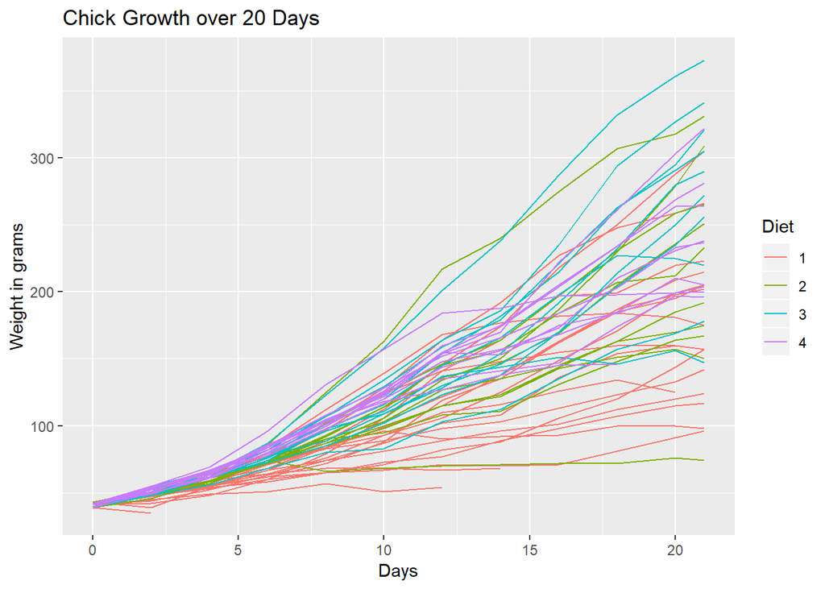

```r
ggplot(data = ChickWeight, mapping = aes(x = Time, y = weight, color = Diet, group = Chick)) +
  geom_line() +
  labs(title = "Chick Growth over 20 Days") +
  xlab("Days") +
  ylab("Weight in grams")
```

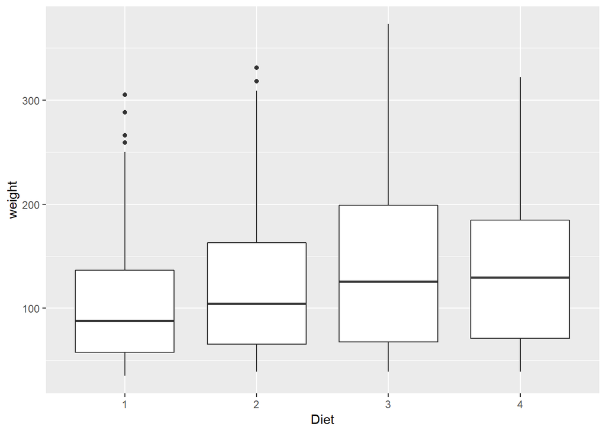

```r
#
adultchick <- ChickWeight %>%
  filter(Time == 20) %>%
  mutate(avgwt = mean(weight))

ggplot(data = ChickWeight) +
  geom_boxplot(mapping = aes(x = Diet, y= weight))
```

These figures are created from the ChickWeight dataset in R datasets’ package originally from Crowder’s Analysis of Repeated Measures. It is a dataset of 50 chicks which are weighed every other day from birth til 20 days and an additional measurement at day 21. Each chick is given a different protein diet. I chose this dataset to showcase some elementary plots and calculations with relatively tame data. By subsetting the data by the time, we can calculate the average weight at day 0 which was 41.06. Additionally, the average weight for a chick that survived till day 20 is 209.7. Using our friendly boxplot, we can see the differences amongst each diet. Diet 1 looks to be the best diet for thinner chicks while diet 3 and 4 would be the go-to diet to maximize weight. This type of analysis can be used by the food industry to maximize their chicken meat production through the choice of diet.

Further research can look at the growth past day 21 and try to model this growth.

Dataset 2: airquality

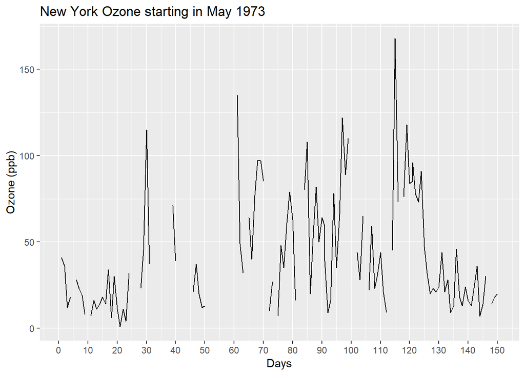

```r
#Create the days variable which converts Month & Day to just Days after May 1
ozone <- airquality %>%
  mutate(days = (Month * 30 + Day)-150)


#Plot for the ozone over time
ggplot(data = ozone, mapping = aes(x = days, y = Ozone)) +
  geom_line() +
  labs(title = "New York Ozone starting in May 1973") +
  xlab("Days") +
  ylab("Ozone (ppb)") +
  scale_x_continuous(breaks = seq(0, 150, by = 10))
```

```r
#Calculate Means per Month
ozone %>%
  group_by(Month) %>%
  filter(!is.na(Ozone)) %>%
  summarise(mean = mean(Ozone))
```

```
## # A tibble: 5 x 2
##   Month  mean
##   <int> <dbl>
## 1     5  23.6
## 2     6  29.4
## 3     7  59.1
## 4     8  60.0
## 5     9  31.4
```

These figures are derived from the New York State Department of Conservation and the National Weather Service. It contains the daily readings of ozone, solar radiation, wind and temperature from May 1, 1973 to September 30, 1973. The highest average ozone is in the month of August with 59.96 ppb with July not far off at 59.1 The best air quality from this dataset is in May with an average of 23.6 ppb. Judging from personal anecdote and the data, I believe the rise in air pollutants may have to do with the use of air conditioning units in the city during the Summer. If possible, in future studies, it would be interesting to see the changes in ozone throughout the entire year if not additional years.

Dataset 3: Orange

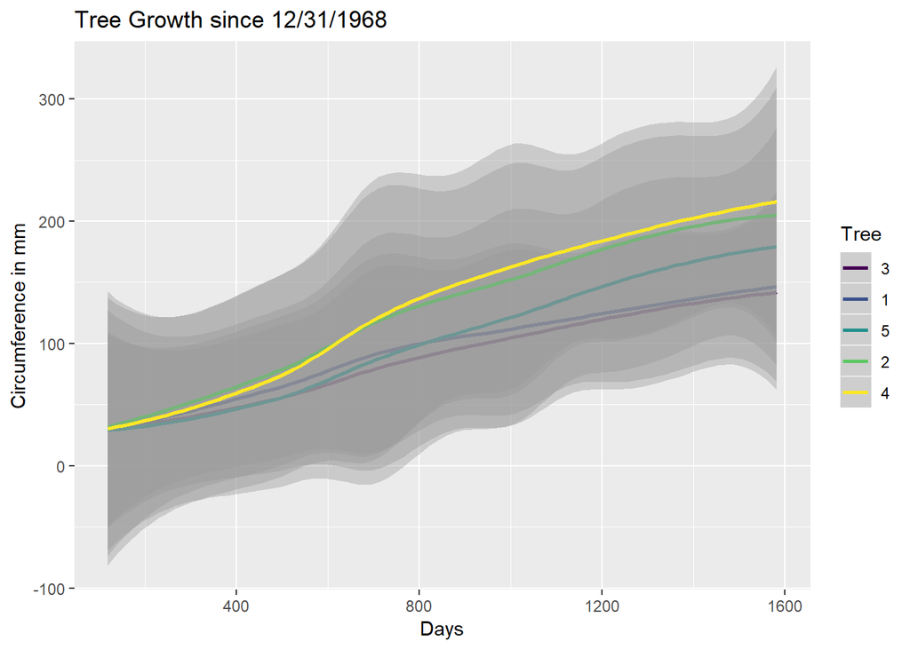

```r
#Linear Model for Orange Tree growth
ggplot(data = Orange, mapping = aes(x = age, y = circumference, group = Tree, color = Tree)) +
  geom_smooth() +
  labs(title = "Tree Growth since 12/31/1968 ") +
  xlab("Days") +
  ylab("Circumference in mm")
```

```r
omax <- Orange%>%
  group_by(Tree) %>%
  mutate(max = max(circumference))
glimpse(omax)
```

```
## Observations: 35
## Variables: 4
## $ Tree          <ord> 1, 1, 1, 1, 1, 1, 1, 2, 2, 2, 2, 2, 2, 2, 3, 3, ...
## $ age           <dbl> 118, 484, 664, 1004, 1231, 1372, 1582, 118, 484,...
## $ circumference <dbl> 30, 58, 87, 115, 120, 142, 145, 33, 69, 111, 156...
## $ max           <dbl> 145, 145, 145, 145, 145, 145, 145, 203, 203, 203...
```

The Orange dataset comes from Draper’s Applied Regression Analysis exercise. It follows the growth of 5 orange trees from 12/31/1968. After every couple hundred days, measurements of the circumference of the 5 trees are taken. The trees are labeled in order of increasing diameter. Tree 1 has a max of 145 mm of trunk which was observed at day 1582. Tree 4 has a max of 214 mm of trunk which was observed at day 1582. This dataset was chosen to study the growth of orange trees and the variance in their growth rate. Additional studies into this topic may include using different fruit trees to see the differences in growth.

Dataset 4: Titanic

```r
data.frame(Titanic)
```

```
##    Class    Sex   Age Survived Freq
## 1    1st   Male Child       No    0
## 2    2nd   Male Child       No    0
## 3    3rd   Male Child       No   35
## 4   Crew   Male Child       No    0
## 5    1st Female Child       No    0
## 6    2nd Female Child       No    0
## 7    3rd Female Child       No   17
## 8   Crew Female Child       No    0
## 9    1st   Male Adult       No  118
## 10   2nd   Male Adult       No  154
## 11   3rd   Male Adult       No  387
## 12  Crew   Male Adult       No  670
## 13   1st Female Adult       No    4
## 14   2nd Female Adult       No   13
```

[output cut: 18 more lines]

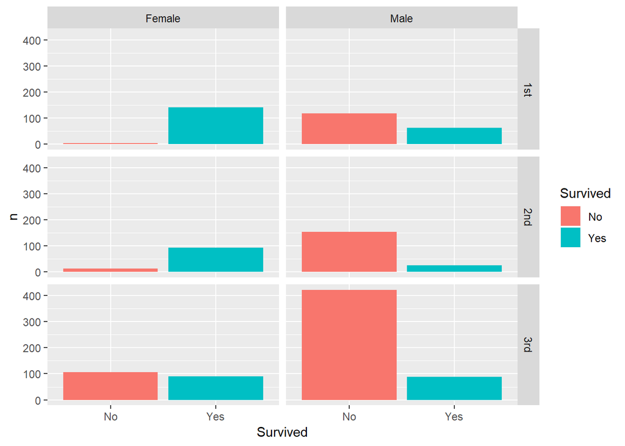

```r
?Titanic
ship <- as_tibble(Titanic) %>%
  filter(Class != 'Crew')


ggplot(data = ship) +
  geom_col(mapping = aes(x = Survived, y = n, fill = Survived)) +
  facet_grid(Class ~ Sex)
```

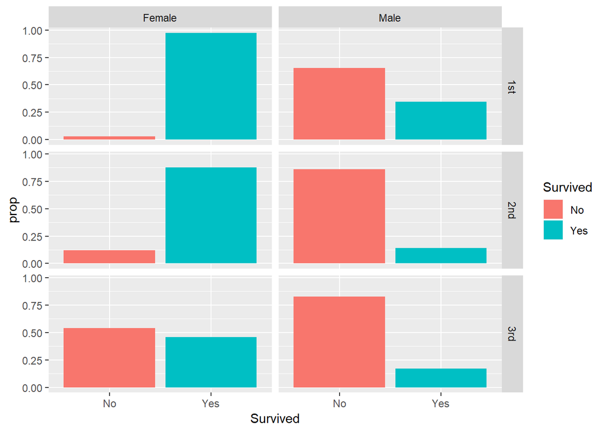

```r
propsurv <- ship %>%
  group_by(Class, Sex) %>%
  mutate(prop = n/sum(n))

ggplot(data = propsurv, mapping = aes(x = Survived, y = prop, fill = Survived)) +
  geom_col() +
  facet_grid(Class ~ Sex)
```

The Titanic data was collected by the British Board of Trade in their investigation of the famous sinking. In this dataset, we have the number of people on board that survived or died categorized into class, sex and age. I filtered out the Crew for analysis because I was more interested in the breakdown of which passengers were prioritized for the lifeboats. From there, I calculated the proportion of people that died in their respective category. From the plot, we can see children and women were highly prioritized and the Class didn’t matter as much for men as most men died regardless of class. For women in the 3rd class, you see that they died at a much higher rate than the women in the upper classes. If this dataset could be improved, I would love to analysize the subgroups within class or other categorical variables like room location on ship, etc.